# Melbourne Racing Statistics

```r
library(bettRtab)
library(tidyverse)
library(lubridate)
library(scales)
library(gt)
library(here)

m_r_race_lists <- readRDS(here("analysis", "racing-statistics", "m_r_race_lists.rds"))
runners_m_r <- parse_runners(m_r_race_lists)

# races21 <- bettRtab::load_race_meet_meta(cal_year = 2021)
# races22 <- bettRtab::load_race_meet_meta(cal_year = 2022)
#
# race_meta <- bind_rows(races21, races22)
# saveRDS(race_meta, here("analysis", "racing-statistics", "race_meta.rds"))

race_meta <- readRDS(here("analysis", "racing-statistics", "race_meta.rds"))

race_meta <- race_meta %>%
  filter(meetingName %in% c("SANDOWN", "CAULFIELD", "FLEMINGTON", "MOONEE VALLEY")) %>%
  select(meetingDate, meetingName, weatherCondition, trackCondition)



# because the initial scrape included Cranbourne to test for errors
runners_m_r <- runners_m_r %>%
  filter(meetingName != "CRANBOURNE") %>%
  left_join(race_meta, by = c("meetingDate", "meetingName")) %>%
  mutate(is_group_race = str_detect(raceClassConditions, "GP"))
```

Data was collected for the tracks listed below for all horse racing events in 2021 and 2022 (up to 2022-09-18).

- Caulfield
- Flemington
- Moonee Valley
- Sandown

There were 1526 individual races analysed over this time frame.

## What are we analysing?

Because we’re going to be largely analysing the win markets, want to analyse some summary stats on the parimutuel (tote) and fixed odds winning market.

## What questions do we want to answer?

1. What price do winners pay?
2. Do favourites always win?
1. and if there is two clear favourites and then roughies, how often do the favs win?
3. Is there a difference between track? Weather? Race class? Number of runners, etc?
4. Is there a way to optimise a quaddie structure - ie if taking field in one leg, and one or two in another, is there an optimal strategy to employ when to take the field or one-out?

Interestingly, both the tote (4354) and fixed markets (123) have zeros, while there were 1704 horses that had a missing fixed odds win price.

Looking at whether the horse ran gives us some info on these missing records.

When looking at the fixed odds status, the result is `NA` (missing).. we can then use the tote status to get some more info and the bulk of these appeared to have run (`Normal`). We can infer from this that there were some races that didn’t have a fixed odds market. From this little analysis, I will remove scratched runners from here on in, but importantly, will keep late scratchings in (might need this info for further analysis). Reasoning behind this is that scratching normally occur well in advance of the race, while late scratchings can happen throughout a race meet, even after exotics have started - quaddies, etc.

```r
runners_m_r <- runners_m_r %>%
  filter(parimutuel.bettingStatus != "Scratched")
```

To clean these missing prices up, I’ve substitued the missing tote values with the fixed odds win price, however there are 17 reords where a $0 tote figure is missing in the fixed odds market all together. These are for late scratchings. Will remove these also, and for the rest, replace the tote with the fixed odds price.

```r
# Will create a column called `treat_tote_care` to identify these.
runners_m_r <- runners_m_r %>%
  mutate(filter_out = case_when(
    parimutuel.returnWin == 0 & is.na(fixedOdds.returnWin) ~ "Y",
    TRUE ~ "N"
  )) %>% filter(filter_out == "N") %>% select(-filter_out) %>%
  mutate(treat_tote_care = case_when(
    parimutuel.returnWin == 0 & fixedOdds.returnWin != 0 ~ "Y",
    TRUE ~ "N"
  )) %>%
  mutate(parimutuel.returnWin = case_when(
    parimutuel.returnWin == 0 ~ fixedOdds.returnWin,
    TRUE ~ parimutuel.returnWin
  ))


# Might also need to do this the other way for the fixed odds prices that are missing. Will call this `treat_fixed_odds_care`.
runners_m_r <- runners_m_r %>%
  mutate(treat_fixed_odds_care = case_when(
    is.na(fixedOdds.returnWin) ~ "Y",
    TRUE ~ "N"
  )) %>%
  mutate(fixedOdds.returnWin = case_when(
    treat_fixed_odds_care == "Y" ~ parimutuel.returnWin,
    TRUE ~ fixedOdds.returnWin
  ))
```

### Winners

Winners generally the lowest odds, not much difference between 2nd and 3rd, then increase in price

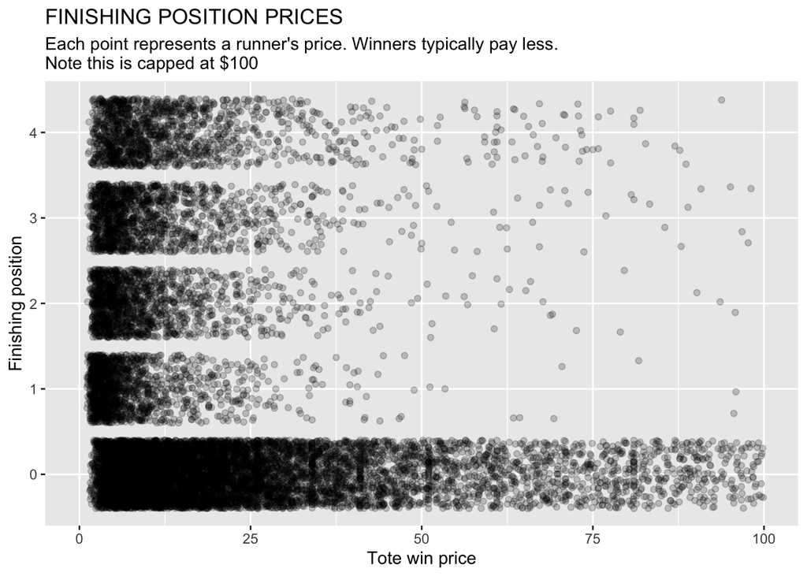

```r
# runners_m_r %>%
#   ggplot(aes(x= parimutuel.returnWin, y= as.character(finishingPosition))) +
#   geom_boxplot() +
#   labs(x="Tote win price", y= "Finishing position") +
#   ggtitle("FINISHING POSITION PRICES")
#   xlim(0, 100)

runners_m_r %>%
  ggplot(aes(x= parimutuel.returnWin, y= as.character(finishingPosition))) +
  geom_jitter(alpha = 0.2) +
  labs(x="Tote win price", y= "Finishing position") +
  ggtitle("FINISHING POSITION PRICES", subtitle = "Each point represents a runner's price. Winners typically pay less.\nNote this is capped at $100") +
  xlim(0, 100)
```

Summary stats for all races show that the median price the winner pays is $5.10. This is for all tracks.

```r
winners %>% pull(parimutuel.returnWin) %>% summary()
```

```
   Min. 1st Qu.  Median    Mean 3rd Qu.    Max.
  1.100   3.100   5.100   8.381   9.600 139.500
```

```r
group_summary <- function(data, ..., x) {
  data %>%                               # Summary by group using dplyr
  group_by(...) %>%
  summarize(n_races = n(),
            min = min({{x}}),
            q1 = quantile({{x}}, 0.25),
            median = median({{x}}),
            mean = mean({{x}}),
            q3 = quantile({{x}}, 0.75),
            max = max({{x}}))
}
```

Breaking this down, there is some variation between track, but not a hell of a lot. Sandown winners pay slightly less.

```r
group_summary(runners_m_r %>% filter(finishingPosition == 1), group=meetingName, x=parimutuel.returnWin)
```

```
# A tibble: 4 × 8
  group         n_races   min    q1 median  mean    q3   max
  <chr>           <int> <dbl> <dbl>  <dbl> <dbl> <dbl> <dbl>
1 CAULFIELD         354   1.2  3.1    5.5   7.94  9.6   70.5
2 FLEMINGTON        360   1.1  3.38   5.3   9.88  9.93 140.
3 MOONEE VALLEY     280   1.1  3.2    5.25  8.49 10.6   40.6
4 SANDOWN           534   1.1  3      4.7   7.61  8.9   63.4
```

When looking at the class of race, The median win price is higher for group races than non-group races, suggesting that if you’re looking for value, group races are where to target slightly higher priced runners.

```r
group_summary(data=runners_m_r %>% filter(finishingPosition == 1), group=is_group_race, x=parimutuel.returnWin)
```

```
# A tibble: 2 × 8
  group n_races   min    q1 median  mean    q3   max
  <lgl>   <int> <dbl> <dbl>  <dbl> <dbl> <dbl> <dbl>
1 FALSE    1497   1.1  3.1     5.1  8.29   9.5  125.
2 TRUE       31   1.8  3.55    6.6 12.7   12.8  140.
```

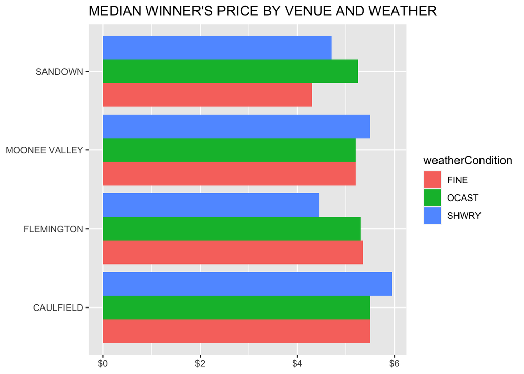

```r
group_summary(data=runners_m_r %>% filter(finishingPosition == 1), group=meetingName, weatherCondition, x=parimutuel.returnWin) %>%
  ggplot(aes(x=median, y=group, fill = weatherCondition)) +
  geom_bar(stat = "identity", position = "dodge") +
  scale_x_continuous(labels = dollar) +
  ggtitle("MEDIAN WINNER'S PRICE BY VENUE AND WEATHER") +
  theme(axis.title = element_blank())
```

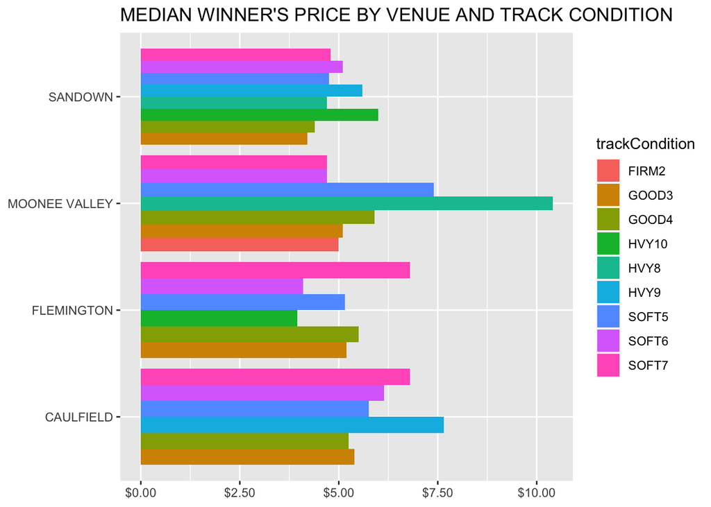

```r
group_summary(data=runners_m_r %>% filter(finishingPosition == 1), group=meetingName, trackCondition, x=parimutuel.returnWin) %>%
  ggplot(aes(x=median, y=group, fill = trackCondition)) +
  geom_bar(stat = "identity", position = "dodge") +
  scale_x_continuous(labels = dollar) +
  ggtitle("MEDIAN WINNER'S PRICE BY VENUE AND TRACK CONDITION") +
  theme(axis.title = element_blank())
```

### Favourites

Turning our attention on the performance of favourites…

```r
# select $2.8 as the heavy fav - it's the 5th percentile. Can change this if needed
heavy_fav_cutoff <- quantile(runners_m_r$parimutuel.returnWin, probs = seq(0, 1, 0.05))["5%"] %>% unname()

runners_m_r <- runners_m_r %>%
  arrange(meetingDate, meetingName, raceNumber, raceName, parimutuel.returnWin) %>%
  group_by(meetingDate, meetingName, raceNumber, raceName) %>%
  mutate(betting_rank = floor(rank(parimutuel.returnWin))) %>% ungroup() %>%
  mutate(heavy_fav = case_when(
    betting_rank == 1 & parimutuel.returnWin <= heavy_fav_cutoff ~ "Y",
    betting_rank == 1 & parimutuel.returnWin > heavy_fav_cutoff ~ "N",
    TRUE ~ "Non Fav"
  ))


runners_m_r <- runners_m_r %>%
  group_by(meetingDate, meetingName, raceNumber, raceName) %>%
  mutate(n_winners = sum(finishingPosition == 1)) %>% ungroup()
```

How often did the favourite win?

Slight variation between tracks, but fav generally wins about 30-35% of the time. At the Valley, they win the least frequently.

```r
runners_m_r %>%
  filter(betting_rank == 1) %>%
  mutate(finishingPosition = factor(finishingPosition, levels = c(1,2,3,4,0))) %>%
  group_by(meetingName, finishingPosition) %>%
  summarise(`Num Wins` = n()) %>%
  mutate(`Num Races` = sum(`Num Wins`),
         `Win %`=`Num Wins` / sum(`Num Wins`)) %>% ungroup() %>%
  filter(finishingPosition == 1) %>%
  select(-finishingPosition) %>%
  mutate(`Win %` = percent(`Win %`, accuracy = 0.1)) %>%
  gt() %>%
  tab_header("FAVOURITE WIN %", subtitle = "Measuring the proportion of races won by a favourite") %>%
  tab_style(
     locations = cells_column_labels(columns = everything()),
     style     = list(
       #Give a thick border below
       cell_borders(sides = "bottom", weight = px(3)),
       #Make text bold
       cell_text(weight = "bold")
     )
   ) %>%
   #Apply different style to the title
   tab_style(
     locations = cells_title(groups = "title"),
     style     = list(
       cell_text(weight = "bold", size = 24)
     )
   )
```

FAVOURITE WIN %

Measuring the proportion of races won by a favourite

| meetingName | Num Wins | Num Races | Win % |
| --- | --- | --- | --- |
| CAULFIELD | 123 | 362 | 34.0% |
| FLEMINGTON | 128 | 369 | 34.7% |
| MOONEE VALLEY | 83 | 286 | 29.0% |
| SANDOWN | 183 | 547 | 33.5% |

What about the finishing position of the favourite?

There’s an equal split by thirds between winning, in the placings and 4th or lower.

```r
runners_m_r %>%
  filter(betting_rank == 1) %>%
  mutate(finishingPosition = factor(finishingPosition, levels = c(1,2,3,4,0))) %>%
  group_by(finishingPosition) %>%
  summarise(`Num Wins` = n()) %>%
  mutate(`Num Races` = sum(`Num Wins`),
         `Win %`=`Num Wins` / sum(`Num Wins`)) %>% ungroup() %>%
  mutate(`Win %` = percent(`Win %`, accuracy = 0.1)) %>%
  gt() %>%
  tab_header("FAVOURITE FINISHING POSITION", subtitle = "Overall finishing positions, for all tracks. The favourite wins a third of the time, finishes in the placings roughly a third of the time, and 4th or lower a third of the time") %>%
  tab_style(
     locations = cells_column_labels(columns = everything()),
     style     = list(
       #Give a thick border below
       cell_borders(sides = "bottom", weight = px(3)),
       #Make text bold
       cell_text(weight = "bold")
     )
   ) %>%
   #Apply different style to the title
   tab_style(
     locations = cells_title(groups = "title"),
     style     = list(
       cell_text(weight = "bold", size = 24)
     )
   )
```

FAVOURITE FINISHING POSITION

Overall finishing positions, for all tracks. The favourite wins a third of the time, finishes in the placings roughly a third of the time, and 4th or lower a third of the time

| finishingPosition | Num Wins | Num Races | Win % |
| --- | --- | --- | --- |
| 1 | 517 | 1564 | 33.1% |
| 2 | 282 | 1564 | 18.0% |
| 3 | 230 | 1564 | 14.7% |
| 4 | 148 | 1564 | 9.5% |
| 0 | 387 | 1564 | 24.7% |

Breaking it down by track shows no real difference:

```r
runners_m_r %>%
  filter(betting_rank == 1) %>%
  mutate(finishingPosition = factor(finishingPosition, levels = c(1,2,3,4,0))) %>%
  group_by(meetingName, finishingPosition) %>%
  summarise(`Num Wins` = n()) %>%
  mutate(`Num Races` = sum(`Num Wins`),
         `Win %`=`Num Wins` / sum(`Num Wins`)) %>% ungroup() %>%
  mutate(`Win %` = percent(`Win %`, accuracy = 0.1)) %>%
  group_by(meetingName) %>%
  gt() %>%
  tab_header("FAVOURITE FINISHING POSITION BY TRACK", subtitle = "Overall finishing positions, by track. No real difference by track.") %>%
  tab_style(
     locations = cells_column_labels(columns = everything()),
     style     = list(
       #Give a thick border below
       cell_borders(sides = "bottom", weight = px(3)),
       #Make text bold
       cell_text(weight = "bold")
     )
   ) %>%
   #Apply different style to the title
   tab_style(
     locations = cells_title(groups = "title"),
     style     = list(
       cell_text(weight = "bold", size = 24)
     )
   )
```

FAVOURITE FINISHING POSITION BY TRACK

Overall finishing positions, by track. No real difference by track.

| finishingPosition | Num Wins | Num Races | Win % |
| --- | --- | --- | --- |
| CAULFIELD |  |  |  |
| 1 | 123 | 362 | 34.0% |
| 2 | 64 | 362 | 17.7% |
| 3 | 59 | 362 | 16.3% |
| 4 | 29 | 362 | 8.0% |
| 0 | 87 | 362 | 24.0% |
| FLEMINGTON |  |  |  |
| 1 | 128 | 369 | 34.7% |
| 2 | 58 | 369 | 15.7% |
| 3 | 41 | 369 | 11.1% |
| 4 | 41 | 369 | 11.1% |
| 0 | 101 | 369 | 27.4% |
| MOONEE VALLEY |  |  |  |
| 1 | 83 | 286 | 29.0% |
| 2 | 57 | 286 | 19.9% |
| 3 | 40 | 286 | 14.0% |
| 4 | 35 | 286 | 12.2% |
| 0 | 71 | 286 | 24.8% |
| SANDOWN |  |  |  |
| 1 | 183 | 547 | 33.5% |
| 2 | 103 | 547 | 18.8% |
| 3 | 90 | 547 | 16.5% |
| 4 | 43 | 547 | 7.9% |
| 0 | 128 | 547 | 23.4% |

### What about when there’s a heavy fav?

There was a heavy fav (in this case any horse paying $2.80 or less), in 736 of 1526 races.

In these 736 races, the win rate of the fav jumped to between 36% and 45%.

**Note:** The implied win probability of a runner paying $2.80 is 35.7%

```r
runners_m_r %>%
  filter(heavy_fav == "Y") %>%
  mutate(finishingPosition = factor(finishingPosition, levels = c(1,2,3,4,0))) %>%
  group_by(meetingName, finishingPosition) %>%
  summarise(`Num Wins` = n()) %>%
  mutate(`Num Races` = sum(`Num Wins`),
         `Win %`=`Num Wins` / sum(`Num Wins`)) %>% ungroup() %>%
  filter(finishingPosition == 1) %>%
  select(-finishingPosition) %>%
  mutate(`Win %` = percent(`Win %`, accuracy = 0.1)) %>%
  gt() %>%
  tab_header("HEAVY FAVOURITE WIN %", subtitle = "Measuring the proportion of races won by a heavy favourite") %>%
  tab_style(
     locations = cells_column_labels(columns = everything()),
     style     = list(
       #Give a thick border below
       cell_borders(sides = "bottom", weight = px(3)),
       #Make text bold
       cell_text(weight = "bold")
     )
   ) %>%
   #Apply different style to the title
   tab_style(
     locations = cells_title(groups = "title"),
     style     = list(
       cell_text(weight = "bold", size = 24)
     )
   )
```

HEAVY FAVOURITE WIN %

Measuring the proportion of races won by a heavy favourite

| meetingName | Num Wins | Num Races | Win % |
| --- | --- | --- | --- |
| CAULFIELD | 78 | 174 | 44.8% |
| FLEMINGTON | 59 | 144 | 41.0% |
| MOONEE VALLEY | 55 | 151 | 36.4% |
| SANDOWN | 113 | 267 | 42.3% |

What if we chucked $100 on every race there was a heavy fav?

There were 734 races with a heavy favourite. That would cost us $73,400.

Here’s the bad news… the return would be $64,712:

> **a loss of -$8,688…**

```r
heavy_favs %>%
  # filter(betting_rank == 1) %>%
  mutate(finishingPosition = factor(finishingPosition, levels = c(1,2,3,4,0))) %>%
  group_by(finishingPosition) %>%
  summarise(`Num Wins` = n()) %>%
  mutate(`Num Races` = sum(`Num Wins`),
         `Win %`=`Num Wins` / sum(`Num Wins`)) %>% ungroup() %>%
  mutate(`Win %` = percent(`Win %`, accuracy = 0.1)) %>%
  gt() %>%
  tab_header("HEAVY FAVOURITE FINISHING POSITION", subtitle = "Overall finishing positions, for all tracks in races where there was a 'heavy' favourite. The favourite wins ~41% of the time, finishes in the placings just over a third of the time, and 4th or lower ~24% of the time") %>%
  tab_style(
     locations = cells_column_labels(columns = everything()),
     style     = list(
       #Give a thick border below
       cell_borders(sides = "bottom", weight = px(3)),
       #Make text bold
       cell_text(weight = "bold")
     )
   ) %>%
   #Apply different style to the title
   tab_style(
     locations = cells_title(groups = "title"),
     style     = list(
       cell_text(weight = "bold", size = 24)
     )
   )
```

HEAVY FAVOURITE FINISHING POSITION

Overall finishing positions, for all tracks in races where there was a 'heavy' favourite. The favourite wins ~41% of the time, finishes in the placings just over a third of the time, and 4th or lower ~24% of the time

| finishingPosition | Num Wins | Num Races | Win % |
| --- | --- | --- | --- |
| 1 | 303 | 734 | 41.3% |
| 2 | 152 | 734 | 20.7% |
| 3 | 106 | 734 | 14.4% |
| 4 | 60 | 734 | 8.2% |
| 0 | 113 | 734 | 15.4% |